# Confronto_tra_Gauss_t_Student

NikolayNikolaev

2023-05-29

Si intende ricavare la distribuzione a posteriori per parametro riferito al punteggio medio di un test utilizzato per le valutazioni di dislessia. Da rilevazioni precedenti si sa che il punteggio mediano è 100 e che un valore plausibile per il 95-esimo percentile della distribuzione a priori del parametro è 120.

Utilizzando la funzione normal.select si ricavano i due momenti della prior

```r
require(LearnBayes)
quantile1 <- list(p=.5,x=100);
quantile2 <- list(p=.95,x=120)
ris <- normal.select(quantile1, quantile2);
mu <- ris$mu; mu
```

```
## [1] 100
```

```r
tau <- ris$sigma; tau
```

```
## [1] 12.15914
```

Da cui $p(\theta) = N(100, 12.16^2)$

Supponendo di aver esaminato 𝑛 = 4 bambini selezionati in modo casuale, ed assumendo $\sigma=15$ (variabilità attesa nella popolazione considerata), si mostrano i momenti della distribuzione a posteriori in base al modello coniugato rispetto al modello in cui la prior è specificata come una distribuzione 𝑡 di Student. In questo contesto la distribuzione 𝑡 avendo code più pesanti comporta una diversa distribuzione a posteriori specialmente se i valori campionari si allontano dal valore medio della distribuzione a priori (Albert, 2009).

Supponiamo ad esempio che le rilevazioni sui 4 bambini forniscano i seguenti tre diversi scenari: $\bar{x_1}= 110 ; \bar{x_2} = 125 ; \bar{x_3} = 140$.

Ovvero nel primo scenario la media più vicina a quella specificata a priori mentre nel terzo scenario è particolarmente lontana.

Se il modello è coniugato come illustrato in precedenza le stime dei parametri della distribuzione a posteriori per ogni scenario si ricavano come segue

```r
sigma <- 15
xnn <- c(110, 125, 140)
n<-4
# deviazione standard
tau12 <- 1/(n/sigma^2 + 1/tau^2); tau12
```

```
## [1] 40.74708
```

```r
# media
mu1 <- (mu*sigma^2 + (n*xnn*tau^2))/(n*tau^2 + sigma^2); mu1
```

```
## [1] 107.2439 118.1098 128.9757
```

```r
# sintesi
summ1 <- cbind(xnn, mu1, tau12)
summ1
```

```
##      xnn      mu1    tau12
## [1,] 110 107.2439 40.74708
## [2,] 125 118.1098 40.74708
## [3,] 140 128.9757 40.74708
```

## Distribuzione a priori T di Student

Invece di utilizzare il modello coniugato supponiamo una distribuzione 𝑡 di Student come prior per la media. Questa distribuzione avendo le code pesanti (ovvero c’è maggiore densità sui valori lontani dalla media rispetto alla normale) permette di tener conto delle osservazioni inusuali nei dati e di valori estremi del parametro per distribuzione a priori. Si caratterizza per i seguenti tre parametri: il valore centrale $\mu$ , la scala $\tau$ e i gradi di liberta $\nu$.

$$P(\frac{\theta - \mu}{\tau } <
\frac{120-100}{\tau}) = 0.95$$

Considerando una $t$ di Student con 2 gadi di liverta’ (si ricorda che se $\nu=1$ la t ha la forma di una Cauchy) si ha

$$P(t_2 < \frac{20}{\tau}) =
0.95$$

si tratta di determinare il quantile di ordine $p$ della distribuzione $T_2(t_2(p))$

```r
qt(0.95, 2)
```

```
## [1] 2.919986
```

ed il valore del parametro di scala che si ottiene dall’equazione
$$\tau = \frac{20}{t_2(p)}$$

da cui risluta:

```r
taut <- 20/qt(0.95,2); taut
```

```
## [1] 6.849349
```

## Confronto tra le due distribuzioni a priori

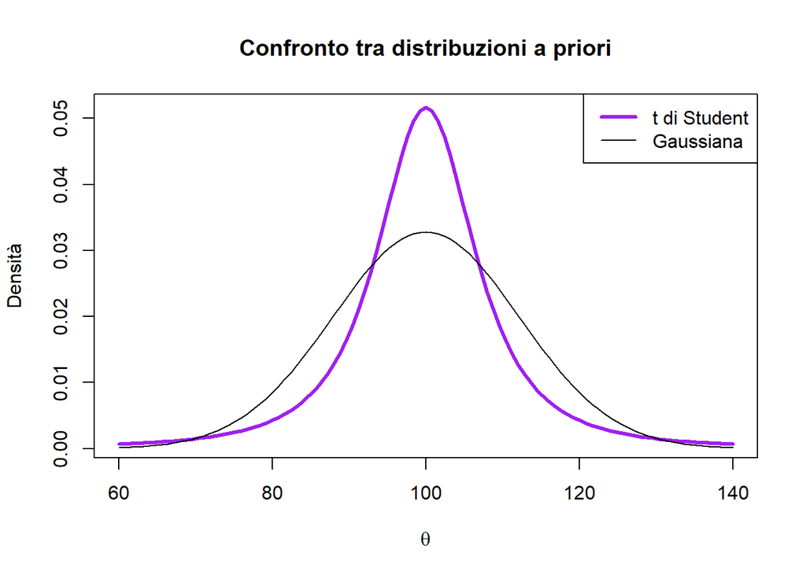

```r
curve(1/taut*dt((x-mu)/taut,2),
    from=60,
    to=140,
    xlab = expression(theta),
    ylab ="Densità",
    main ="Confronto tra distribuzioni a priori",
    col ='purple',
    lwd=3)
curve(dnorm(x,mean=mu,sd=tau),
      add=TRUE,
    lwd=1)
legend("topright",
       legend=c("t di Student","Gaussiana"),
       lwd=c(3,1),
       col=c("purple", "black"))
```

## Determinazione della distribuzione a posteriori

La distribuzione a posterori è proporzionale al prodotto della verosimiglianza del modello e della distribuzione a priori

$$p(\theta|x) \varpropto\phi(\bar{x} |
\theta, \frac{\sigma}{\sqrt{n}}).g_t(\theta| \nu, \mu,
\tau)$$

La densità a posteriori in questo si ottiene nel modo seguente approssimando la distribuzione continua con una sua discretizzazione su una griglia di valori.

Si genera una sequenza di valori (griglia di valori possibili per il parametro) e si approssima la densità continua con una distribuzione discreta su questa griglia.

```r
theta <- seq(60, 180, length = 500)
summary(theta)
```

```
##    Min. 1st Qu.  Median    Mean 3rd Qu.    Max.
##      60      90     120     120     150     180
```

Si calcolano i valori della verosimiglianza riferiti al valore medio considerando $𝑛 = 4$

```r
n <- 4
like <- dnorm(theta,mean=xnn,sd=sigma/sqrt(n))
summary(like)
```

```
##      Min.   1st Qu.    Median      Mean   3rd Qu.      Max.
## 0.000e+00 0.000e+00 1.687e-05 8.317e-03 7.223e-03 5.318e-02
```

Si determinano i valori del parametro di posizione e di scala della distribuzione a posteriori dopo averla normalizzata

```r
prior <- dt((theta - mu)/taut, 2)
post <- prior * like
post <- post/sum(post)
posizione <- sum(theta * post)
scala <- sqrt(sum(theta^2 * post) - posizione^2)
```

Il procedimento precedente può essere riassunto con la seguente funzione che in output restituisce i valori attesi (locazione e scala) della distribuzione a posteriori ed in input richiede il vettore delle medie.

```r
norm.t.compute <- function(xnn){
  theta <- seq(60, 180, length = 500)
  like <- dnorm(theta,mean=xnn,sd=sigma/sqrt(n))
  prior <- dt((theta - mu)/taut, 2)
  post <- prior * like
  post <- post/sum(post)
  posizione <- sum(theta * post)
  scala <- sqrt(sum(theta^2 * post) - posizione^2)
c(xnn, posizione, scala)
}
```

Utilizzando la funzione sapply si applica la funzione al vettore delle medie 𝑥𝑛𝑛 osservate e si ottengono i parametri della distribuzione a posteriori.

```r
summ2<- t(sapply(c(110, 125, 140),norm.t.compute))
dimnames(summ2)[[2]] =
c("xnn","mu1 t","tau1 t")
summ2
```

```
##      xnn    mu1 t   tau1 t
## [1,] 110 105.2921 5.841676
## [2,] 125 118.0841 7.885174
## [3,] 140 135.4134 7.973498
```

```r
cbind(summ1,summ2)
```

```
##      xnn      mu1    tau12 xnn    mu1 t   tau1 t
## [1,] 110 107.2439 40.74708 110 105.2921 5.841676
## [2,] 125 118.1098 40.74708 125 118.0841 7.885174
## [3,] 140 128.9757 40.74708 140 135.4134 7.973498
```

L’inferenza sulla media (diversamente dalla mediana) è molto sensibile a cambiamenti rispetto ai valori campionari. Si dice in questo caso che non è un’inferenza robusta come quella della mediana.

La scelta della distribuzione a priori Normale o 𝑡 di Student comporta circa la stessa stima puntuale del parametro a posteriori per valori osservati della media campionaria non particolarmente estremi rispetto a quelli medi a priori.

Per valori campionari estremi la stima fornita dal modello coniugato è 129 mentre quella fornita dalla scelta della 𝑡 di Student come prior è 135 e assicura maggiore aderenza alle osservazioni campionarie.